# Paper Airplane

### Experiment Design

**Introduction**

This experiment is on the effect of paper design on flight distance. Three different paper airplane designs were used : Basic, Basic dart, stable.

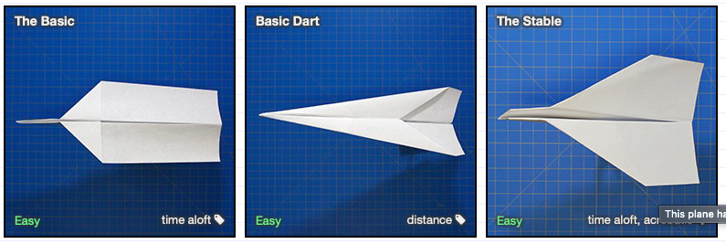

The hypothesis is as follows:

$$H_0: \mu_1 = \mu_2 = \mu_3\ = \mu$$

$$H_a: \mu_i \neq 0 \ \text{for at least one}\ i \in \ \{1= basic, 2= basic dart, 3= stable\}$$

The significant level for the test:
$$\alpha = 0.05$$

**Method**

1. Fold each of the paper airplanes with 8.5 * 11 inches copier paper. 10 times per design. - Made from same person for the purpose of consistency and uniformity.
2. Use a random generator to decide which order the planes were fold - Eliminate the bias of folding one type of design continuously. Folding one type of airplane consistently causes the airplane design to become more advanced. Randomization included.
3. Perform experiment indoors(performed in a game room without obstacles) - Use controlled environment to avoid factors that might affect results: wind, objects, damage on plane.
4. Tape the floor where you start flying the airplane. Make sure you fly the plane at the same height by the same person. The person who’s throwing the plane shouldn’t know the order of plane design. Randomize the order of throws by using the random generator. - Consistency, control environment to avoid bias from thrower.
5. Tape the point where plane tail landed. Label what design of plane was thrown to keep track of them.
6. After all the planes are thrown, measure the distance from the bottom part of the start line tape to the top part of landing point.

#### Airplane Data

```r
datatable(airplane)
```

|  | airplane | distance |
| --- | --- | --- |
| 1 | basic | 24.5 |
| 2 | basic | 28.6 |
| 3 | basic | 55.6 |
| 4 | basic | 46.5 |
| 5 | basic | 26.4 |
| 6 | basic | 28.4 |
| 7 | basic | 57.5 |
| 8 | basic | 47.6 |
| 9 | basic | 72 |
| 10 | basic | 45.2 |

[output cut: 20 more lines]

### Analysis

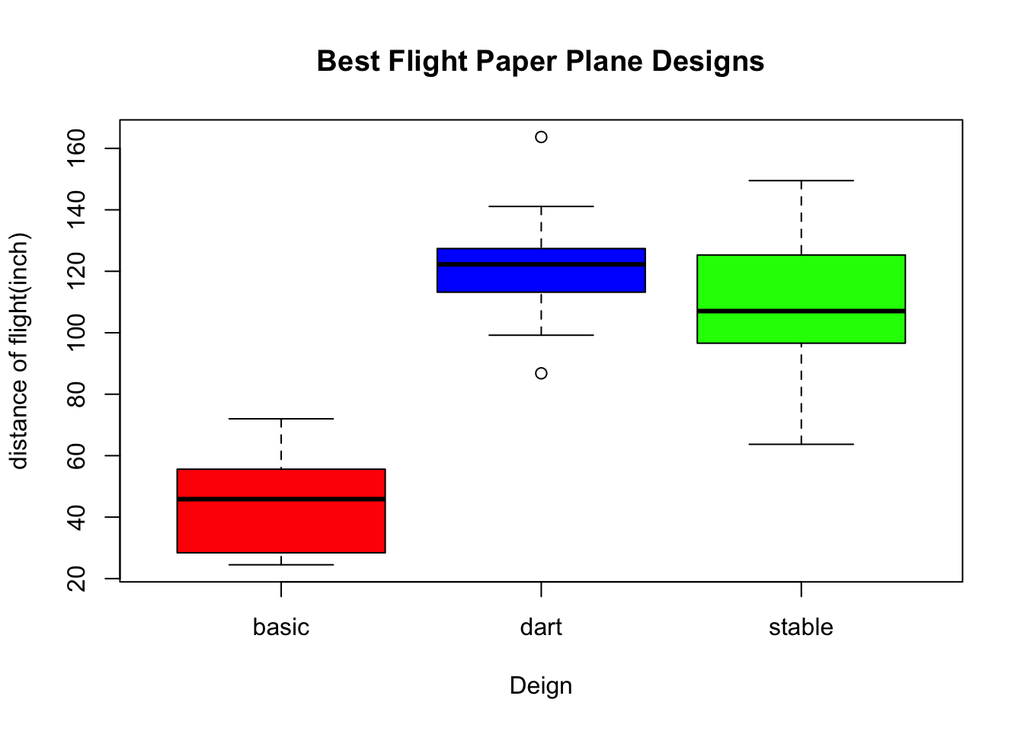

```r
boxplot(distance ~ airplane, data=airplane, names = c("basic", "dart", "stable"), col=c("red","blue","green"), xlab="Deign", ylab="distance of flight(inch)", main = "Best Flight Paper Plane Designs")
```

```r
pander(favstats(distance~airplane, data=airplane))
```

| airplane | min | Q1 | median | Q3 | max | mean | sd | n | missing |
| --- | --- | --- | --- | --- | --- | --- | --- | --- | --- |
| basic | 24.5 | 28.45 | 45.85 | 53.6 | 72 | 43.23 | 15.94 | 10 | 0 |
| dart | 86.8 | 114.2 | 122.2 | 127.1 | 163.7 | 122 | 21.19 | 10 | 0 |
| stable | 63.7 | 97.85 | 107.1 | 124.3 | 149.5 | 106.8 | 26.22 | 10 | 0 |

Thick lines on each box shows the median of each data set. Dart median is 122 which is higher than the other two airplane designs. Basic median is the lowest among three designs. Stable design has a wide range of data.

**follow up**

Since the ANOVA test is significant, I performed Tukey HSD pairwise test to compare each factor level to all other factor levels to confirm which designs have different designs.

```r
airplane$airplane <- as.factor(airplane$airplane)
myaov <- aov(distance ~ airplane, data=airplane, contrasts=list(airplane=contr.sum))
pander(TukeyHSD(myaov))
```

- **airplane**:

  |  | diff | lwr | upr | p adj |
  | --- | --- | --- | --- | --- |
  | **dart-basic** | 78.73 | 54.86 | 102.6 | 2.603e-08 |
  | **stable-basic** | 63.54 | 39.67 | 87.41 | 1.302e-06 |
  | **stable-dart** | -15.19 | -39.06 | 8.682 | 0.2723 |

Dart-basic and stable-basic are different designs comparing one another because their p-value is below 0.05. However, stable-dart design is equivalently same.

**Assumption**

Check conclusion to see the interpretation.

```r
pander(summary(myaov))
```

Analysis of Variance Model

|  | Df | Sum Sq | Mean Sq | F value | Pr(>F) |
| --- | --- | --- | --- | --- | --- |
| **airplane** | 2 | 34888 | 17444 | 37.64 | 1.555e-08 |
| **Residuals** | 27 | 12514 | 463.5 | NA | NA |

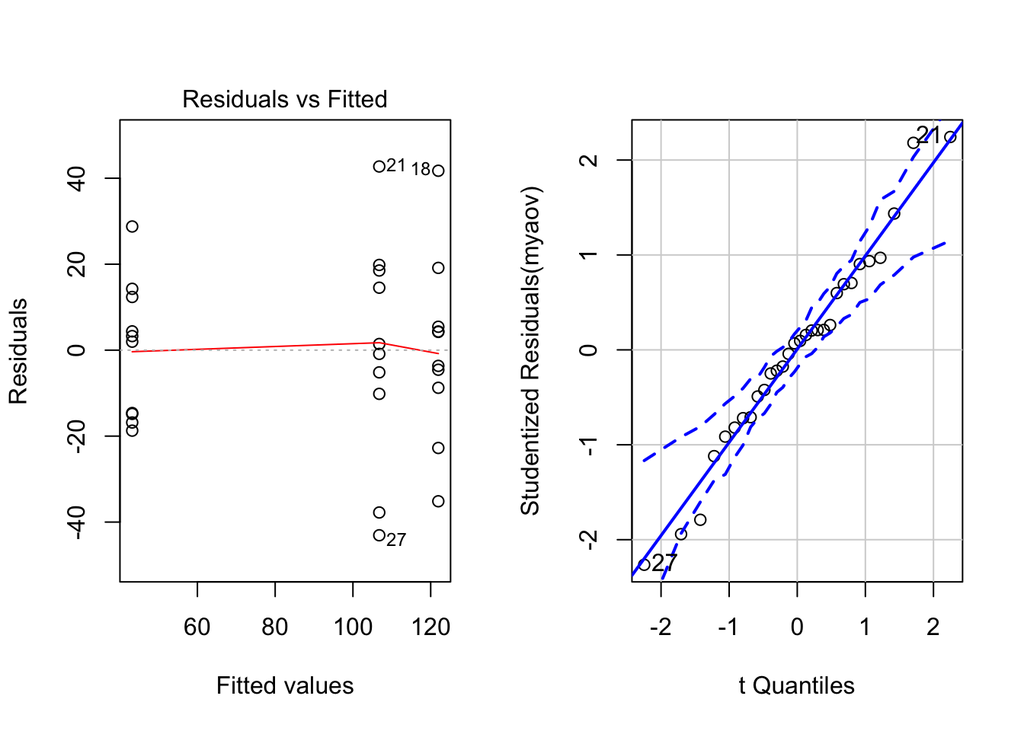

```
## [1] 21 27
```

```r
par(mfrow=c(1,2))
plot(myaov, which=(1:1))
qqPlot(myaov)
```

With the Residual vs Fitted graph, the assumption for constant variance looks good. If you find a pattern in the graph, it means there something more in data you can interpret. With Normal Q-Q Plot, which is second graph, shows that assumption for normality is reasonable. All dots following straight line. In other words, the error terms are considered to be normal.

### Conclusion

P-value is 1.555e-08(which is smaller than significant level=0.05). There is sufficient evidence to reject the null hypothesis. Therefore, there is a statically significant difference between at least one of airplane design and another. Stable and dart design has longer thrown distance, but their designs are pretty much the same from pairwise test. I will choose either stable or dart deign for the experiment. Representatives and uniformity is a little tricky in this experiment because it uses only three different paper airplanes.